# Statistical Inference Project 2

Frog

Wednesday, August 06, 2014

### 1. Load the ToothGrowth data and perform some basic exploratory data analyses

```r
library(ggplot2)
data(ToothGrowth)
str(ToothGrowth)
```

```
## 'data.frame':    60 obs. of  3 variables:
##  $ len : num  4.2 11.5 7.3 5.8 6.4 10 11.2 11.2 5.2 7 ...
##  $ supp: Factor w/ 2 levels "OJ","VC": 2 2 2 2 2 2 2 2 2 2 ...
##  $ dose: num  0.5 0.5 0.5 0.5 0.5 0.5 0.5 0.5 0.5 0.5 ...
```

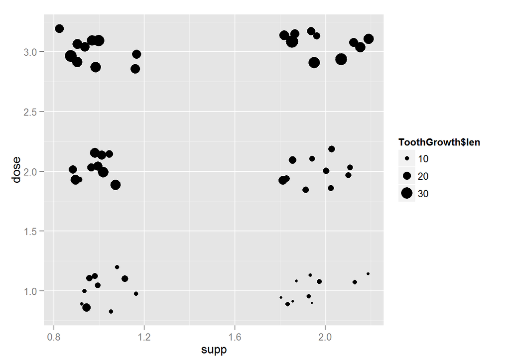

```r
ToothGrowth$dose<-as.factor(ToothGrowth$dose)
qplot(jitter(as.numeric(ToothGrowth$supp)),jitter(as.numeric(ToothGrowth$dose)),
      size=ToothGrowth$len,ylab="dose",xlab="supp")
```

We can see that as the dose increases the length of the teeth increases but comparing the same dose levels it is difficult to see if the supplement type has an effect. It seems that the supllement type OJ (factor level 1) produces slightly longer teeth than supplement VC (factor level 2)

### 2. Provide a basic summary of the data.

```r
summary(ToothGrowth)
```

```
##       len       supp     dose
##  Min.   : 4.2   OJ:30   0.5:20
##  1st Qu.:13.1   VC:30   1  :20
##  Median :19.2           2  :20
##  Mean   :18.8
##  3rd Qu.:25.3
##  Max.   :33.9
```

You ask it, you got it.

### 3. Use confidence intervals and hypothesis tests to compare tooth growth by supp and dose.

First I would like to test if the dose has an effect so I will split the dataset in just two parts: dose==0.5 and dose==2 to compare the higher and lower doses and its effect on Teeth length.

```r
group1<-ToothGrowth[ToothGrowth$dose==0.5,1]
group2<-ToothGrowth[ToothGrowth$dose==2,1]
```

Now I perform a t test assuming the groups are not paired

```r
t.test(group1,group2,paired=FALSE)
```

```
##
##  Welch Two Sample t-test
##
## data:  group1 and group2
## t = -11.8, df = 36.88, p-value = 4.398e-14
## alternative hypothesis: true difference in means is not equal to 0
## 95 percent confidence interval:
##  -18.16 -12.83
## sample estimates:
## mean of x mean of y
##     10.61     26.10
```

We can see that the dose effectively has an effect in tooth growth

Now I do the same for the supplement type

```r
group1<-ToothGrowth[ToothGrowth$supp=="VC",1]
group2<-ToothGrowth[ToothGrowth$supp=="OJ",1]
```

I repeat the same test

```r
t.test(group1,group2,paired=FALSE)
```

```
##
##  Welch Two Sample t-test
##
## data:  group1 and group2
## t = -1.915, df = 55.31, p-value = 0.06063
## alternative hypothesis: true difference in means is not equal to 0
## 95 percent confidence interval:
##  -7.571  0.171
## sample estimates:
## mean of x mean of y
##     16.96     20.66
```

### 4. State your conclusions and the assumptions needed for your conclusions.

I assumed the tests were done in different populations and that the population size is enough to draw conclusions.